# ETC5521 Diving Deeper into Data Exploration: Assignment 3

Author

Caoyu Shao

Published

September 22, 2025

## Question 1

Article 3 is broadly correct: men tend to read fewer books—especially literature—than women, although the difference is modest. When “reading” is expanded to include news, magazines, and online content, the gap narrows further and is often not statistically significant. Taken together, the three articles point to a wider trend: overall reading has declined across the population. Focusing blame solely on men risks obscuring broader, systemic issues—and the solutions needed to address them.

## Question 2

### A) Questions

In which activities are gender differences (gap between males and females) increasing or decreasing between younger and older generations?

How do the proportions of “active activities” (sports, going out) and “passive activities” (watching TV, surfing the Internet) compare across generations?

Is there a “typical leisure mix”? For example, are people who prefer sports also more likely to participate in cultural activities, and do people who watch TV also spend more time online?

### B) IDA

#### Load the data

First, we load the dataset. Because the file contains multiple worksheets, I import them individually, sheet by sheet.

```r
library(readxl)

library(dplyr)
path <-"data/ABS_leisure_2022.xlsx"



df_2022_1 <- read_excel(path,sheet = "Table 1.1",skip = 4)
df_2022_2 <- read_excel(path,sheet = "Table 1.2",skip = 4)
df_2022_3 <- read_excel(path,sheet = "Table 1.3",skip = 4)
df_2022_4 <- read_excel(path,sheet = "Table 1.4",skip = 4)
df_2022_5 <- read_excel(path,sheet = "Table 1.5",skip = 4)
df_2022_6 <- read_excel(path,sheet = "Table 1.6",skip = 4)
df_2022_7 <- read_excel(path,sheet = "Table 1.7",skip = 4)
```

#### Delete the irrelevant information

The dataset includes a confidentiality and disclosure-controls statement and a copyright notice appended at the end. While these notices are essential, we temporarily remove them during analysis to maintain a tidy working data frame; they will be reinstated in the final deliverable.

```r
df_2022_1 <-df_2022_1 |> head(-4)
df_2022_2 <-df_2022_2 |> head(-4)
df_2022_3 <-df_2022_3 |> head(-4)
df_2022_4 <-df_2022_4 |> head(-4)
df_2022_5 <-df_2022_5 |> head(-4)
df_2022_6 <-df_2022_6 |> head(-4)
df_2022_7 <-df_2022_7 |> head(-2)
```

#### Pivot longer to a panel data

Table 1.1 reports the percentage of people who participated. Because it is not in panel (tidy) form and is inconvenient for subsequent analyses, I reshape it to a long format. The same applies to Tables 1.2–1.6, which are likewise pivoted to long.

```r
library(readxl)
library(dplyr)
library(tidyr)
library(janitor)
df_2022_1_z <- df_2022_1 |> select(1,2,3,4) |>
  rename(name =1, Males =2, Females =3,Persons =4) |>slice(-1,-2)
df_2022_1_z_longer <- df_2022_1_z |>
  rename(name=1) |>
  pivot_longer(
    cols= -name,
    names_to = "gender",
    values_to = "value"
    )|> mutate(group = "generation_Z")

df_2022_1_M <- df_2022_1 |> select(1,5,6,7)|>
  rename(name =1, Males =2, Females=3, Persons =4) |> slice(-1,-2)
df_2022_1_M_longer <- df_2022_1_M |>
  rename(name=1) |>
  pivot_longer(
    cols= -name,
    names_to = "gender",
    values_to = "value"
    )|> mutate(group = "Millennials")

df_2022_1_X <- df_2022_1 |> select(1,8,9,10)|>
  rename(name =1, Males =2, Females=3, Persons =4) |> slice(-1,-2)
df_2022_1_X_longer <- df_2022_1_X |>
  rename(name=1) |>
  pivot_longer(
    cols= -name,
    names_to = "gender",
    values_to = "value"
    )|> mutate(group = "generation_X")

df_2022_1_B <- df_2022_1 |> select(1,11,12,13)|>
  rename(name =1, Males =2, Females=3, Persons =4) |> slice(-1,-2)
df_2022_1_B_longer <- df_2022_1_B |>
  rename(name=1) |>
  pivot_longer(
    cols= -name,
    names_to = "gender",
    values_to = "value"
    )|> mutate(group = "Baby_booms")

df_2022_1_I <- df_2022_1 |> select(1,14,15,16)|>
  rename(name =1, Males =2, Females=3, Persons =4) |> slice(-1,-2)
df_2022_1_I_longer <- df_2022_1_I |>
  rename(name=1) |>
  pivot_longer(
    cols= -name,
    names_to = "gender",
    values_to = "value"
    )|> mutate(group = "Interwar")



df_2022_1_longer <-
  bind_rows(df_2022_1_z_longer,
            df_2022_1_M_longer,
            df_2022_1_X_longer,
            df_2022_1_B_longer,
            df_2022_1_I_longer)

df_2022_2_z <- df_2022_2 |> select(1,2,3,4) |>
  rename(name =1, Males =2, Females =3,Persons =4) |>slice(-1,-2)
df_2022_2_z_longer <- df_2022_2_z |>
  rename(name=1) |>
  pivot_longer(
    cols= -name,
    names_to = "gender",
    values_to = "value"
    )|> mutate(group = "generation_Z")

df_2022_2_M <- df_2022_2 |> select(1,5,6,7)|>
  rename(name =1, Males =2, Females=3, Persons =4) |> slice(-1,-2)
df_2022_2_M_longer <- df_2022_2_M |>
  rename(name=1) |>
  pivot_longer(
    cols= -name,
    names_to = "gender",
    values_to = "value"
    )|> mutate(group = "Millennials")

df_2022_2_X <- df_2022_2 |> select(1,8,9,10)|>
  rename(name =1, Males =2, Females=3, Persons =4) |> slice(-1,-2)
df_2022_2_X_longer <- df_2022_2_X |>
  rename(name=1) |>
  pivot_longer(
    cols= -name,
    names_to = "gender",
    values_to = "value"
    )|> mutate(group = "generation_X")

df_2022_2_B <- df_2022_2 |> select(1,11,12,13)|>
  rename(name =1, Males =2, Females=3, Persons =4) |> slice(-1,-2)
df_2022_2_B_longer <- df_2022_2_B |>
  rename(name=1) |>
  pivot_longer(
    cols= -name,
    names_to = "gender",
    values_to = "value"
    )|> mutate(group = "Baby_booms")

df_2022_2_I <- df_2022_2 |> select(1,14,15,16)|>
  rename(name =1, Males =2, Females=3, Persons =4) |> slice(-1,-2)
df_2022_2_I_longer <- df_2022_2_I |>
  rename(name=1) |>
  pivot_longer(
    cols= -name,
    names_to = "gender",
    values_to = "value"
    )|> mutate(group = "Interwar")



df_2022_2_longer <-
  bind_rows(df_2022_2_z_longer,
            df_2022_2_M_longer,
            df_2022_2_X_longer,
            df_2022_2_B_longer,
            df_2022_2_I_longer)



df_2022_3_z <- df_2022_3 |> select(1,2,3,4) |>
  rename(name =1, Males =2, Females =3,Persons =4) |>slice(-1,-2)
df_2022_3_z_longer <- df_2022_3_z |>
  rename(name=1) |>
  pivot_longer(
    cols= -name,
    names_to = "gender",
    values_to = "value"
    )|> mutate(group = "generation_Z")

df_2022_3_M <- df_2022_3 |> select(1,5,6,7)|>
  rename(name =1, Males =2, Females=3, Persons =4) |> slice(-1,-2)
df_2022_3_M_longer <- df_2022_3_M |>
  rename(name=1) |>
  pivot_longer(
    cols= -name,
    names_to = "gender",
    values_to = "value"
    )|> mutate(group = "Millennials")

df_2022_3_X <- df_2022_3 |> select(1,8,9,10)|>
  rename(name =1, Males =2, Females=3, Persons =4) |> slice(-1,-2)
df_2022_3_X_longer <- df_2022_3_X |>
  rename(name=1) |>
  pivot_longer(
    cols= -name,
    names_to = "gender",
    values_to = "value"
    )|> mutate(group = "generation_X")

df_2022_3_B <- df_2022_3 |> select(1,11,12,13)|>
  rename(name =1, Males =2, Females=3, Persons =4) |> slice(-1,-2)
df_2022_3_B_longer <- df_2022_3_B |>
  rename(name=1) |>
  pivot_longer(
    cols= -name,
    names_to = "gender",
    values_to = "value"
    )|> mutate(group = "Baby_booms")

df_2022_3_I <- df_2022_3 |> select(1,14,15,16)|>
  rename(name =1, Males =2, Females=3, Persons =4) |> slice(-1,-2)
df_2022_3_I_longer <- df_2022_3_I |>
  rename(name=1) |>
  pivot_longer(
    cols= -name,
    names_to = "gender",
    values_to = "value"
    )|> mutate(group = "Interwar")



df_2022_3_longer <-
  bind_rows(df_2022_3_z_longer,
            df_2022_3_M_longer,
            df_2022_3_X_longer,
            df_2022_3_B_longer,
            df_2022_3_I_longer)

df_2022_4_z <- df_2022_4 |> select(1,2,3,4) |>
  rename(name =1, Males =2, Females =3,Persons =4) |>slice(-1,-2)
df_2022_4_z_longer <- df_2022_4_z |>
  rename(name=1) |>
  pivot_longer(
    cols= -name,
    names_to = "gender",
    values_to = "value"
    )|> mutate(group = "generation_Z")

df_2022_4_M <- df_2022_4 |> select(1,5,6,7)|>
  rename(name =1, Males =2, Females=3, Persons =4) |> slice(-1,-2)
df_2022_4_M_longer <- df_2022_4_M |>
  rename(name=1) |>
  pivot_longer(
    cols= -name,
    names_to = "gender",
    values_to = "value"
    )|> mutate(group = "Millennials")

df_2022_4_X <- df_2022_4 |> select(1,8,9,10)|>
  rename(name =1, Males =2, Females=3, Persons =4) |> slice(-1,-2)
df_2022_4_X_longer <- df_2022_4_X |>
  rename(name=1) |>
  pivot_longer(
    cols= -name,
    names_to = "gender",
    values_to = "value"
    )|> mutate(group = "generation_X")

df_2022_4_B <- df_2022_4 |> select(1,11,12,13)|>
  rename(name =1, Males =2, Females=3, Persons =4) |> slice(-1,-2)
df_2022_4_B_longer <- df_2022_4_B |>
  rename(name=1) |>
  pivot_longer(
    cols= -name,
    names_to = "gender",
    values_to = "value"
    )|> mutate(group = "Baby_booms")

df_2022_4_I <- df_2022_4 |> select(1,14,15,16)|>
  rename(name =1, Males =2, Females=3, Persons =4) |> slice(-1,-2)
df_2022_4_I_longer <- df_2022_4_I |>
  rename(name=1) |>
  pivot_longer(
    cols= -name,
    names_to = "gender",
    values_to = "value"
    )|> mutate(group = "Interwar")



df_2022_4_longer <-
  bind_rows(df_2022_4_z_longer,
            df_2022_4_M_longer,
            df_2022_4_X_longer,
            df_2022_4_B_longer,
            df_2022_4_I_longer)

df_2022_5_z <- df_2022_5 |> select(1,2,3,4) |>
  rename(name =1, Males =2, Females =3,Persons =4) |>slice(-1,-2)
df_2022_5_z_longer <- df_2022_5_z |>
  rename(name=1) |>
  pivot_longer(
    cols= -name,
    names_to = "gender",
    values_to = "value"
    )|> mutate(group = "generation_Z")

df_2022_5_M <- df_2022_5 |> select(1,5,6,7)|>
  rename(name =1, Males =2, Females=3, Persons =4) |> slice(-1,-2)
df_2022_5_M_longer <- df_2022_5_M |>
  rename(name=1) |>
  pivot_longer(
    cols= -name,
    names_to = "gender",
    values_to = "value"
    )|> mutate(group = "Millennials")

df_2022_5_X <- df_2022_5 |> select(1,8,9,10)|>
  rename(name =1, Males =2, Females=3, Persons =4) |> slice(-1,-2)
df_2022_5_X_longer <- df_2022_5_X |>
  rename(name=1) |>
  pivot_longer(
    cols= -name,
    names_to = "gender",
    values_to = "value"
    )|> mutate(group = "generation_X")

df_2022_5_B <- df_2022_5 |> select(1,11,12,13)|>
  rename(name =1, Males =2, Females=3, Persons =4) |> slice(-1,-2)
df_2022_5_B_longer <- df_2022_5_B |>
  rename(name=1) |>
  pivot_longer(
    cols= -name,
    names_to = "gender",
    values_to = "value"
    )|> mutate(group = "Baby_booms")

df_2022_5_I <- df_2022_5 |> select(1,14,15,16)|>
  rename(name =1, Males =2, Females=3, Persons =4) |> slice(-1,-2)
df_2022_5_I_longer <- df_2022_5_I |>
  rename(name=1) |>
  pivot_longer(
    cols= -name,
    names_to = "gender",
    values_to = "value"
    )|> mutate(group = "Interwar")



df_2022_5_longer <-
  bind_rows(df_2022_5_z_longer,
            df_2022_5_M_longer,
            df_2022_5_X_longer,
            df_2022_5_B_longer,
            df_2022_5_I_longer)

df_2022_6_z <- df_2022_6 |> select(1,2,3,4) |>
  rename(name =1, Males =2, Females =3,Persons =4) |>slice(-1,-2)
df_2022_6_z_longer <- df_2022_6_z |>
  rename(name=1) |>
  pivot_longer(
    cols= -name,
    names_to = "gender",
    values_to = "value"
    )|> mutate(group = "generation_Z")

df_2022_6_M <- df_2022_6 |> select(1,5,6,7)|>
  rename(name =1, Males =2, Females=3, Persons =4) |> slice(-1,-2)
df_2022_6_M_longer <- df_2022_6_M |>
  rename(name=1) |>
  pivot_longer(
    cols= -name,
    names_to = "gender",
    values_to = "value"
    )|> mutate(group = "Millennials")

df_2022_6_X <- df_2022_6 |> select(1,8,9,10)|>
  rename(name =1, Males =2, Females=3, Persons =4) |> slice(-1,-2)
df_2022_6_X_longer <- df_2022_6_X |>
  rename(name=1) |>
  pivot_longer(
    cols= -name,
    names_to = "gender",
    values_to = "value"
    )|> mutate(group = "generation_X")

df_2022_6_B <- df_2022_6 |> select(1,11,12,13)|>
  rename(name =1, Males =2, Females=3, Persons =4) |> slice(-1,-2)
df_2022_6_B_longer <- df_2022_6_B |>
  rename(name=1) |>
  pivot_longer(
    cols= -name,
    names_to = "gender",
    values_to = "value"
    )|> mutate(group = "Baby_booms")

df_2022_6_I <- df_2022_6 |> select(1,14,15,16)|>
  rename(name =1, Males =2, Females=3, Persons =4) |> slice(-1,-2)
df_2022_6_I_longer <- df_2022_6_I |>
  rename(name=1) |>
  pivot_longer(
    cols= -name,
    names_to = "gender",
    values_to = "value"
    )|> mutate(group = "Interwar")



df_2022_6_longer <-
  bind_rows(df_2022_6_z_longer,
            df_2022_6_M_longer,
            df_2022_6_X_longer,
            df_2022_6_B_longer,
            df_2022_6_I_longer)
```

#### Unify the data to the decimal point version

Many values in the data frame carry excessive decimal precision. To improve readability and maintain consistency, we standardize the numeric format to one decimal place.

```r
library(dplyr)
library(readr)

df_2022_1_longer  <-
  df_2022_1_longer |>
  mutate(
    value_raw = readr::parse_number(value),
    value_1dp = round(value_raw, 1)
  )


df_2022_2_longer  <-
  df_2022_2_longer |>
  mutate(
    value_raw = readr::parse_number(value),
    value_1dp = round(value_raw, 1)
  )

df_2022_3_longer  <-
  df_2022_3_longer |>
  mutate(
    value_raw = readr::parse_number(value),
    value_1dp = round(value_raw, 1)
  )

df_2022_4_longer  <-
  df_2022_4_longer |>
  mutate(
    value_raw = readr::parse_number(value),
    value_1dp = round(value_raw, 1)
  )

df_2022_5_longer  <-
  df_2022_5_longer |>
  mutate(
    value_raw = readr::parse_number(value),
    value_1dp = round(value_raw, 1)
  )

df_2022_6_longer  <-
  df_2022_6_longer |>
  mutate(
    value_raw = readr::parse_number(value),
    value_1dp = round(value_raw, 1)
  )
```

#### Check the data

We found no missing values (NAs) or outliers in Tables 1.1–1.5. However, in Table 1.6 the relative standard error (RSE) is unavailable for two cells: (i) male Generation Z, Playing games and puzzles (average time), and (ii) male Millennials, Listening to music, radio, podcast (average time). Both entries are flagged “not available for publication.”

#### Simplify generation names

```r
df_2022_1_longer <- df_2022_1_longer %>%
  mutate(group = case_when(
    group == "generation_Z" ~ "Z",
    group == "Millennials"  ~ "M",
    group == "generation_X" ~ "X",
    group == "Baby_booms"   ~ "B",
    group == "Interwar"     ~ "I",
    TRUE ~ group
  ))

df_2022_3_longer <- df_2022_3_longer %>%
  mutate(group = case_when(
    group == "generation_Z" ~ "Z",
    group == "Millennials"  ~ "M",
    group == "generation_X" ~ "X",
    group == "Baby_booms"   ~ "B",
    group == "Interwar"     ~ "I",
    TRUE ~ group
  ))
```

### C)Analysis to address questions

#### 1)In which activities are gender differences (gap between males and females) increasing or decreasing between younger and older generations in participation rate?

To answer this question, we first define the gender gap as the difference between the male and female values on the outcome of interest:

$\text{Gender gap}_{activity, age} = \text{Participation rate}_{male} - \text{Participation rate}_{female}$.

For participation rates we report percentage-point (pp) differences; for time measures we report minutes per day. Positive values indicate men > women; negative values indicate women > men.

```r
# load the packages
library(dplyr)
library(tidyr)
library(ggplot2)
library(forcats)
library(stringr)
library(readr)
library(broom)
library(DT)

df_2022_1_longer <- df_2022_1_longer |>
  mutate(
    value_percent = if_else(value_1dp >1, value_1dp/100,value_1dp))



gaps <- df_2022_1_longer |>
  filter(gender !="Persons")|>
  select(name, group, gender, value_percent) |>
  mutate(gender = tolower(as.character(gender))) |>
  pivot_wider(
    names_from = gender, values_from = value_percent
  ) |>
  filter(name !="Total activities")|>
  filter(name !="Social and community interaction")|>
  filter(name !="Recreation and leisure")|>
  filter(name !="Free time")

gaps <- gaps |>
  mutate(
    gender_gap = males - females
  ) |>
  arrange(name, group)


num_cols <- which(sapply(gaps, is.numeric))

datatable(
  gaps,
  rownames = FALSE,
  escape = TRUE,
  extensions = c("Buttons","FixedHeader"),
  options = list(
    pageLength = 25,
    dom = "Bfrtip",
    fixedHeader = TRUE
  )
)|>
  formatPercentage(columns = num_cols, digits = 1)
```

Table 1: Gender_Gap_for_Activities_across_Generations

| name | group | males | females | gender_gap |
| --- | --- | --- | --- | --- |
| Digital games | B | 0.044 | 0.06 | -0.01599999999999999 |
| Digital games | I | 0.043 | 0.073 | -0.03 |
| Digital games | M | 0.172 | 0.058 | 0.114 |
| Digital games | X | 0.062 | 0.043 | 0.019 |
| Digital games | Z | 0.37 | 0.075 | 0.295 |
| Eating and drinking out | B | 0.139 | 0.167 | -0.02799999999999997 |
| Eating and drinking out | I | 0.141 | 0.159 | -0.01800000000000002 |
| Eating and drinking out | M | 0.154 | 0.139 | 0.01499999999999999 |
| Eating and drinking out | X | 0.134 | 0.171 | -0.03700000000000001 |
| Eating and drinking out | Z | 0.119 | 0.154 | -0.03499999999999999 |

[output cut: 60 more lines]

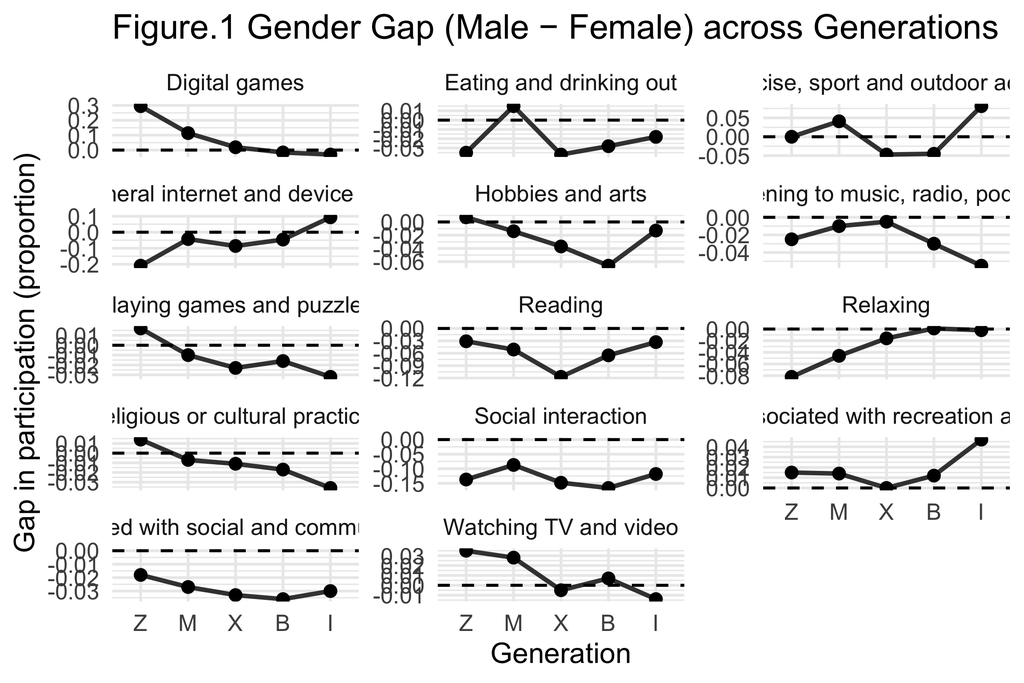

```r
order <- c("Z","M","X","B","I")

p1 <- ggplot(gaps, aes(x = group, y = gender_gap, group = name)) +
  geom_hline(yintercept = 0, linewidth = 0.6, linetype = "dashed") +
  geom_line(linewidth = 0.9, alpha = 0.8) +
  geom_point(size = 2) +
  facet_wrap(~ name, ncol = 3, scales = "free_y") +
  labs(
    title = "Figure.1 Gender Gap (Male − Female) across Generations",
    x = "Generation", y = "Gap in participation (proportion)"
  ) +
   scale_x_discrete(limits = order, drop = FALSE) +
  theme_minimal(base_size = 12)
print(p1)
```

Findings from Figure 1

Digital games: Men participate more than women, and the gap narrows with age.

Eating and drinking out: Women participate more except among Millennials.

Exercise, sport, and outdoor activity: Mixed pattern—parity in Gen Z; men higher in Millennials; women higher in Gen X and Baby Boomers.

Hobbies and arts: Women participate more, peaking among Baby Boomers.

Listening to music, radio, and podcasts: Women participate more; the smallest gap is in Gen X.

Playing games and puzzles: Generally higher for women, except in Gen Z, where men are slightly higher.

Reading: Higher among women.

Relaxing: Higher among women, with a shrinking gap over cohorts.

Religious or cultural practices: Higher among women, with a widening gap.

Social interaction: Higher among women.

Travel associated with recreation and leisure: Higher among men.

Travel associated with social and community interaction: Higher among women.

Watching TV and videos: Higher among men, with a narrowing gap.

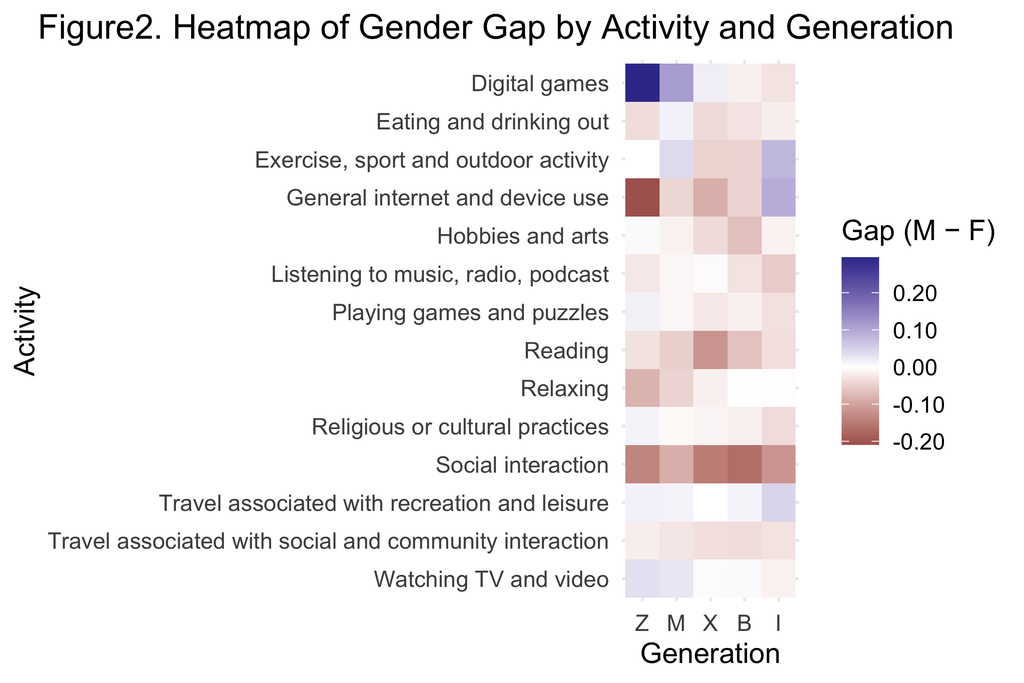

```r
p2 <- ggplot(gaps, aes(x = group, y = fct_rev(name), fill = gender_gap)) +
  geom_tile() +
  scale_fill_gradient2(
    midpoint = 0,
    name = "Gap (M − F)",
    labels = scales::label_number(accuracy = 0.01)
  ) +
  labs(
    title = "Figure2. Heatmap of Gender Gap by Activity and Generation",
    x = "Generation", y = "Activity"
  ) +
  scale_x_discrete(limits = order, drop = FALSE) +
  theme_minimal(base_size = 12) +
  theme(
    plot.title.position = "plot",
    plot.title = element_text(hjust = 0.3)
  )
print(p2)
```

This heat map shows gender gaps across generations and activities; darker shading indicates a larger gap in magnitude. Among Generation Z, males participate in digital games far more than females. By contrast, Generation Z females show higher participation in general internet and device use as well as social interaction. Overall, digital games are more popular among males and relaxing is more popular among females; for both activities, the gender gap narrows across cohorts. For the remaining activities, the gap does not consistently converge to zero.

#### 2)How do the proportions of “active activities” (sports, going out) and “passive activities” (watching TV, surfing the Internet) compare across generations?

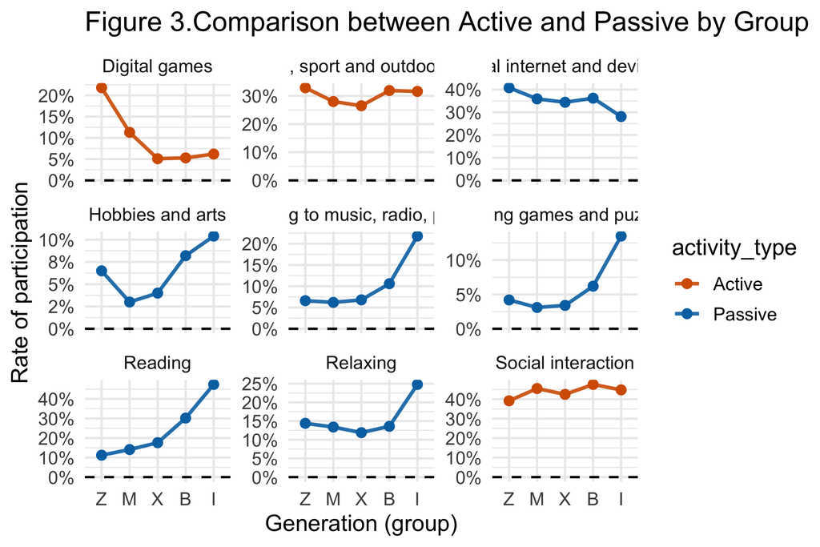

```r
active_set <- c(
  "Exercise, sport and outdoor activity",
  "Social interaction",
   "Digital games"
)
passive_set <- c(
  "Reading",
  "Hobbies and arts",
  "Playing games and puzzles",
  "Watching TV and videos",
  "Listening to music, radio, podcast",
  "Relaxing",
   "General internet and device use"
)
travel_mixed <- c(
  "Travel associated with social and community interaction",
  "Travel associated with recreation and leisure"
)
religious_mixed <- c(
  "Religious or cultural practices"
)
eatout_mixed <- c(
  "Eating and drinking out"
)

df_2022_1_longer <- df_2022_1_longer |>
  mutate(
    activity_type = case_when(
      name %in% active_set  ~ "Active",
      name %in% passive_set ~ "Passive",
      name %in% travel_mixed ~ "Mixed (Travel)",
      name %in% religious_mixed ~ "Mixed (Religious/Cultural)",
      name %in% eatout_mixed ~ "Mixed (Eating/Drinking)",
      TRUE ~ "Other"
    )
  )


PA <- df_2022_1_longer |>
  filter(activity_type %in% c("Active","Passive"))|>
  select(name,gender, value_percent,activity_type,group)|>
  filter(gender %in% c("Persons"))

library(dplyr)
library(ggplot2)
library(scales)


order <- c("Z","M","X","B","I")


PA2 <- PA |>
  mutate(group = trimws(toupper(group))) |>
  mutate(group = factor(group, levels = order))


p <- ggplot(PA2, aes(x = group, y = value_percent,
                     color = activity_type, group = activity_type)) +
  geom_hline(yintercept = 0, linewidth = 0.6, linetype = "dashed") +
  geom_line(linewidth = 0.9, alpha = 0.9) +
  geom_point(size = 2) +
  facet_wrap(~ name, ncol = 3, scales = "free_y") +
  labs(
    title = "Figure 3.Comparison between Active and Passive by Group",
    x = "Generation (group)", y = "Rate of participation"
  ) +
  scale_x_discrete(limits = order, drop = FALSE) +
  scale_y_continuous(labels = percent_format(accuracy = 1)) +
  theme_minimal(base_size = 12)

print(p)
```

```r
library(dplyr)
library(lubridate)


df_2022_3_longer <- df_2022_3_longer |>
  mutate(mins = time_length(hm(value), unit = "minute"))|>
  filter(!name %in% c("Free time", "Recreation and leisure","Social and community interaction","Travel associated with social and community interaction", "Travel associated with recreation and leisure"))
```

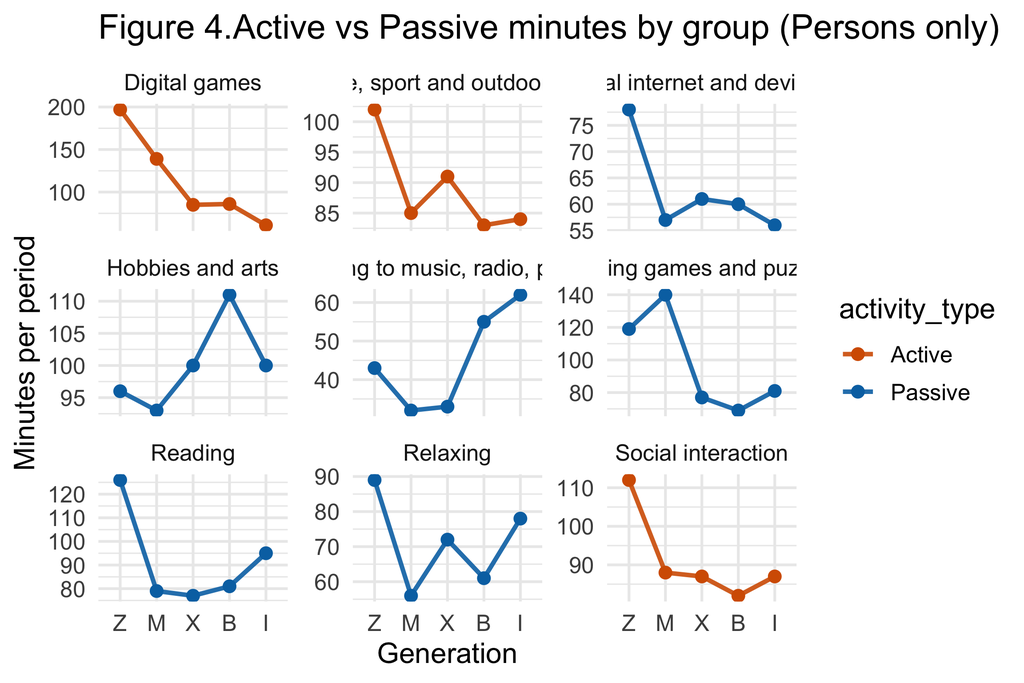

```r
library(dplyr)
library(ggplot2)

active_set <- c(
  "Exercise, sport and outdoor activity",
  "Social interaction",
   "Digital games"
)
passive_set <- c(
  "Reading",
  "Hobbies and arts",
  "Playing games and puzzles",
  "Watching TV and videos",
  "Listening to music, radio, podcast",
  "Relaxing",
   "General internet and device use"
)
travel_mixed <- c(
  "Travel associated with social and community interaction",
  "Travel associated with recreation and leisure"
)
religious_mixed <- c(
  "Religious or cultural practices"
)
eatout_mixed <- c(
  "Eating and drinking out"
)

df_2022_3_longer <- df_2022_3_longer |>
  mutate(
    activity_type = case_when(
      name %in% active_set  ~ "Active",
      name %in% passive_set ~ "Passive",
      name %in% travel_mixed ~ "Mixed (Travel)",
      name %in% religious_mixed ~ "Mixed (Religious/Cultural)",
      name %in% eatout_mixed ~ "Mixed (Eating/Drinking)",
      TRUE ~ "Other"
    )
  )

order <- c("Z","M","X","B","I")

df_use <- df_2022_3_longer |>
  filter(gender == "Persons",
         activity_type %in% c("Active","Passive")) |>
  mutate(
    group = factor(toupper(trimws(group)), levels = order),
    mins  = as.numeric(mins)   # ensure numeric
  )


p_line <- ggplot(df_use,
                 aes(x = group, y = mins, color = activity_type, group = activity_type)) +
  geom_line(linewidth = 0.9, alpha = 0.9) +
  geom_point(size = 2) +
  facet_wrap(~ name, ncol = 3, scales = "free_y") +
  labs(title = "Figure 4.Active vs Passive minutes by group (Persons only)",
       x = "Generation", y = "Minutes per period") +
  theme_minimal(base_size = 12)
print(p_line)
```

```r
library(tidyr)
library(reshape2)

# Wide: rows = group, cols = activity, values = mins (sum over Active/Passive)
mat_wide <- df_2022_3_longer |>
  filter(gender == "Persons") |>
  mutate(group = factor(toupper(trimws(group)), levels = order)) |>
  group_by(group, name) |>
  summarise(mins = sum(as.numeric(mins), na.rm = TRUE), .groups = "drop") |>
  pivot_wider(names_from = name, values_from = mins)

grp <- mat_wide$group
X   <- mat_wide |> select(-group) |> as.data.frame()

# Row-demean so we focus on mix rather than overall heavier/lighter groups
Xc <- t(apply(X, 1, function(r) r - mean(r, na.rm = TRUE)))
colnames(Xc) <- colnames(X); rownames(Xc) <- grp

C <- cor(Xc, use = "pairwise.complete.obs")
```

Focusing on digital games, exercise, sport and outdoor activity, and social interaction, younger cohorts spend more time on these active activities than older cohorts. For general internet and device use, Generation Z records the highest time. Baby Boomers devote the most time to hobbies and arts, while the Interwar cohort spends the most time listening to music, radio, and podcasts—possibly reflecting habits formed when radio was more prevalent. Millennials spend the most time on games and puzzles. Notably, Generation Z also reports the highest reading time, which may be driven by academic requirements.

[figure not shown]

```r
library(ggplot2)
library(reshape2)
library(stringr)
library(grid)

hc  <- hclust(as.dist(1 - C))
ord <- hc$order
C_ord <- C[ord, ord]

C_df <- melt(C_ord, varnames = c("act_i","act_j"), value.name = "corr")

p <- ggplot(C_df, aes(act_i, act_j, fill = corr)) +
  geom_tile() +
  scale_fill_gradient2(limits = c(-1, 1), midpoint = 0, name = "Corr") +
  labs(
    title = "Figure 5.Activity–Activity correlation",
    x = NULL, y = NULL
  ) +

  scale_x_discrete(labels = function(x) str_wrap(x, width = 18)) +
  scale_y_discrete(labels = function(x) str_wrap(x, width = 18)) +
  coord_equal() +
  theme_minimal(base_size = 16) +
  theme(
    axis.text.x = element_text(angle = 45, hjust = 1, vjust = 1, lineheight = 0.95),
    axis.text.y = element_text(lineheight = 0.95),
    legend.title = element_text(size = 12),
    legend.text  = element_text(size = 10),
    legend.key.height = unit(6, "mm"),
    legend.key.width  = unit(6, "mm"),
    plot.margin = margin(10, 20, 10, 20)
  )+
  theme(
    plot.title.position = "plot",
    plot.title = element_text(hjust = 0.3)
  )

print(p)
```

```r
ggsave("corr_heatmap.png", p, width = 12, height = 10, dpi = 320)
```

## Question 3

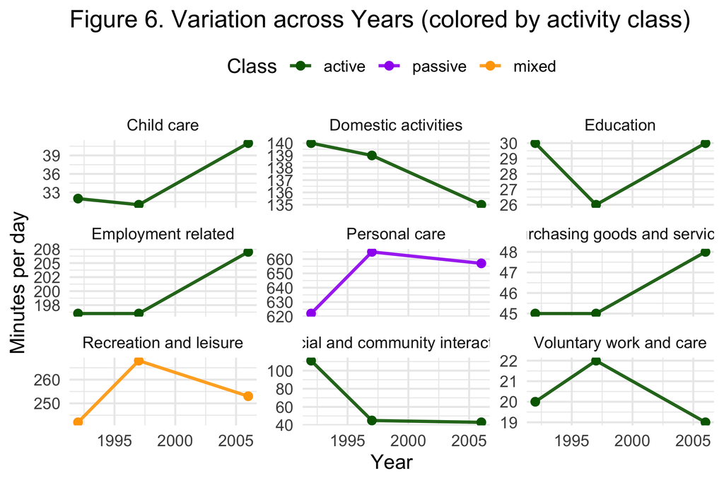

```r
path <- "data/ABS_leisure_historic.xlsx"

df_historic <- read_excel(path,sheet= "Table 1",skip =3)|> head(-4)

df_historic_1992 <- df_historic |> select(1,2,3,4) |>
  rename(name =1, males=2, females=3, persons=4)

library(dplyr)
df_historic_1992 <- df_historic_1992 %>% slice(-(1:3))


df_historic_1997 <- df_historic |> select(1,5,6,7) |>
  rename(name =1, males=2, females=3, persons=4)

df_historic_1997 <- df_historic_1997 %>% slice(-(1:3))

df_historic_2006 <- df_historic |> select(1,8,9,10) |>
  rename(name =1, males=2, females=3, persons=4)

df_historic_2006 <- df_historic_2006 %>% slice(-(1:3))

df_historic_1992_longer <- df_historic_1992 |>
  rename(name=1) |>
  pivot_longer(
    cols= -name,
    names_to = "gender",
    values_to = "value"
    )|> mutate(year = "1992")


df_historic_1997_longer <- df_historic_1997 |>
  rename(name=1) |>
  pivot_longer(
    cols= -name,
    names_to = "gender",
    values_to = "value"
    )|> mutate(year = "1997")

df_historic_2006_longer <- df_historic_2006 |>
  rename(name=1) |>
  pivot_longer(
    cols= -name,
    names_to = "gender",
    values_to = "value"
    )|> mutate(year = "2006")

df_historic_longer <- bind_rows(
  df_historic_1992_longer,
  df_historic_1997_longer,
  df_historic_2006_longer
)

library(lubridate)
df_historic_longer <- df_historic_longer |>
  mutate(mins = time_length(hm(value), unit = "minute"))


df_historic_longer_selected <- df_historic_longer |> filter(name %in% c("Personal care","Employment related","Education", "Domestic activities","Child care","Purchasing goods and services","Voluntary work and care","Social and community interaction", "Recreation and leisure"))


library(dplyr)
library(stringr)
library(ggplot2)
library(scales)

df_1 <- df_historic_longer_selected %>%
  mutate(
    gender = tolower(trimws(gender)),
    year   = as.integer(readr::parse_number(year)),
    mins   = as.numeric(mins),
    name   = str_squish(name)
  ) %>%
  filter(gender == "persons") %>%
  arrange(name, year)


classify_activity <- function(x) {
  case_when(
    str_detect(x, regex("^\\s*personal\\s*care\\s*$", TRUE)) ~ "passive",
    str_detect(x, regex("^\\s*employment\\s*related\\s*$", TRUE)) ~ "active",
    str_detect(x, regex("^\\s*education\\s*$", TRUE)) ~ "active",
    str_detect(x, regex("^\\s*domestic\\s*activities\\s*$", TRUE)) ~ "active",
    str_detect(x, regex("^\\s*child\\s*care\\s*$", TRUE)) ~ "active",
    str_detect(x, regex("^\\s*purchasing\\s+goods\\s+and\\s+services\\s*$", TRUE)) ~ "active",
    str_detect(x, regex("^\\s*voluntary\\s+work\\s+and\\s+care\\s*$", TRUE)) ~ "active",
    str_detect(x, regex("^\\s*social\\s+and\\s+community\\s+interaction\\s*$", TRUE)) ~ "active",
    str_detect(x, regex("^\\s*recreation\\s+and\\s+leisure\\s*$", TRUE)) ~ "mixed",
    TRUE ~ "other"
  )
}

df_1 <- df_1 %>%
  mutate(
    activity_class = classify_activity(name),
    activity_class = factor(activity_class, levels = c("active","passive","mixed","other"))
  )


p_line <- ggplot(df_1, aes(x = year, y = mins, color = activity_class)) +
  geom_line(linewidth = 0.9, alpha = 0.9) +
  geom_point(size = 2) +
  facet_wrap(~ name, ncol = 3, scales = "free_y") +
  scale_x_continuous(breaks = pretty_breaks()) +
  scale_color_manual(
    values = c(
      active  = "darkgreen",
      passive = "purple",
      mixed   = "orange",
      other   = "grey"
    ),
    drop = TRUE
  ) +
  labs(
    title = "Figure 6. Variation across Years (colored by activity class)",
    x = "Year", y = "Minutes per day",
    color = "Class"
  ) +
  theme_minimal(base_size = 12) +
  theme(legend.position = "top")

print(p_line)
```

From Figure 6, time use shifts between 1992, 1997, and 2006 show clear patterns. Time spent on child care increased, while domestic activities declined. Education dipped and then recovered. Employment-related time rose, as did personal care, with a sharp increase between 1992–1997. Time spent purchasing goods and services also increased, especially 1997–2006. Recreation and leisure peaked around 1997 but was lower in 1992 and 2006. Social and community interaction fell markedly. Voluntary work was higher around 1997, but lower in 1992 and 2006. Overall, people devoted more time to family-related activities and self-care, and more time to work, while social/community engagement declined.

## Resources

The materials used for this report are:

Wickham H, Averick M, Bryan J, Chang W, McGowan LD, François R, Grolemund G, Hayes A, Henry L, Hester J, Kuhn M, Pedersen TL, Miller E, Bache SM, Müller K, Ooms J, Robinson D, Seidel DP, Spinu V, Takahashi K, Vaughan D, Wilke C, Woo K, Yutani H (2019). “Welcome to the tidyverse.” *Journal of Open Source Software*, *4*(43), 1686. [doi:10.21105/joss.01686](https://doi.org/10.21105/joss.01686).

Wickham H (2023). *conflicted: An Alternative Conflict Resolution Strategy*. R package version 1.2.0, https://CRAN.R-project.org/package=conflicted.

Wickham H, Bryan J (2025). *readxl: Read Excel Files*. R package version 1.4.5, https://CRAN.R-project.org/package=readxl.

Wickham H, François R, Henry L, Müller K, Vaughan D (2023). *dplyr: A Grammar of Data Manipulation*. R package version 1.1.4, https://CRAN.R-project.org/package=dplyr.

Wickham H, Vaughan D, Girlich M (2024). *tidyr: Tidy Messy Data*. R package version 1.3.1, https://CRAN.R-project.org/package=tidyr.

Firke S (2024). *janitor: Simple Tools for Examining and Cleaning Dirty Data*. R package version 2.2.1, https://CRAN.R-project.org/package=janitor.

Wickham H, Hester J, Bryan J (2024). *readr: Read Rectangular Text Data*. R package version 2.1.5, https://CRAN.R-project.org/package=readr.

H. Wickham. ggplot2: Elegant Graphics for Data Analysis. Springer-Verlag New York, 2016.

Wickham H (2023). *forcats: Tools for Working with Categorical Variables (Factors)*. R package version 1.0.0, https://CRAN.R-project.org/package=forcats.

Wickham H (2023). *stringr: Simple, Consistent Wrappers for Common String Operations*. R package version 1.5.1, https://CRAN.R-project.org/package=stringr.

Robinson D, Hayes A, Couch S (2025). *broom: Convert Statistical Objects into Tidy Tibbles*. R package version 1.0.9, https://CRAN.R-project.org/package=broom.

Xie Y, Cheng J, Tan X (2024). *DT: A Wrapper of the JavaScript Library ‘DataTables’*. R package version 0.33, https://CRAN.R-project.org/package=DT.

Wickham H, Pedersen T, Seidel D (2025). *scales: Scale Functions for Visualization*. R package version 1.4.0, https://CRAN.R-project.org/package=scales.

Garrett Grolemund, Hadley Wickham (2011). Dates and Times Made Easy with lubridate. Journal of Statistical Software, 40(3), 1-25. URL https://www.jstatsoft.org/v40/i03/.

Hadley Wickham (2007). Reshaping Data with the reshape Package. Journal of Statistical Software, 21(12), 1-20. URL http://www.jstatsoft.org/v21/i12/.

R Core Team (2025). *R: A Language and Environment for Statistical Computing*. R Foundation for Statistical Computing, Vienna, Austria. https://www.R-project.org/.

The links to my use of ChatGPT for help on this assignment are:

- https://chatgpt.com/share/68d3a59f-f1c8-8000-9b12-211b91bb55ea helped to construct the regex to process the duration variable.